# R Notebook

# Statistical analysis preface

# Data extraction, transformation and loading

## TMR Data

`r`r TMR <- read.csv2(.csv) TMR$Total <- NULL TMR$Quantity <- NULL TMR_wide <- dcast(TMR, Herd + Sieve ~ Sample) ## reshape table - wide format

`r`r TMR_wide[TMR_wide == ] <- NA TMR_wide$mean <- rowMeans(TMR_wide[,3:12], na.rm = TRUE) ## Mean Sample 1 - 10 TMR_wide$diff <- (TMR_wide$refusals - TMR_wide$mean)/TMR_wide$mean ## relative difference between mean and orts TMR_matrix <- as.matrix(TMR_wide[,3:12]) TMR_wide$sd <- rowSds(TMR_matrix, na.rm = TRUE) ## Standard deviation CV <- function(mean, sd) { (sd/mean)*100 } TMR_wide$cv <- CV(mean = TMR_wide$mean, sd = TMR_wide$sd) ## Coefficient of variation in TMR_wide$cv

### Making a new matrix with the means, cv, orts

`r`r Herd <- matrix(TMR_wide$Herd, ncol = 3, byrow=TRUE) colnames(Herd) <- c(\Herd1\,\Herd2\, \Herd\) mean <- matrix(TMR_wide$mean, ncol = 3, byrow = TRUE) colnames(mean) <- c(.mid.mean,.pan.mean, .top.mean) cv <- matrix(TMR_wide$cv, ncol = 3, byrow = TRUE) colnames(cv) <- c(\FRESH.mid.cv\,\FRESH.pan.cv\, \FRESH.top.cv\) diff <- matrix(TMR_wide$diff, ncol = 3, byrow = TRUE) colnames(diff) <- c(.mid,.pan, .top) TMR_table <- data.frame(Herd, mean, cv, diff) TMR_table <- na.omit(TMR_table[,3:12])

`r`r summary(TMR_table)

```
      Herd    FRESH.mid.mean   FRESH.pan.mean   FRESH.top.mean     FRESH.mid.cv
 Herd 1 : 1   Min.   :0.1571   Min.   :0.2523   Min.   :0.01517   Min.   : 1.727
 Herd 10: 1   1st Qu.:0.3018   1st Qu.:0.3400   1st Qu.:0.16129   1st Qu.: 6.189
 Herd 11: 1   Median :0.3858   Median :0.3962   Median :0.21991   Median : 9.906
 Herd 12: 1   Mean   :0.3748   Mean   :0.3970   Mean   :0.22818   Mean   :11.562
 Herd 13: 1   3rd Qu.:0.4266   3rd Qu.:0.4643   3rd Qu.:0.28163   3rd Qu.:13.500
 Herd 14: 1   Max.   :0.5444   Max.   :0.5586   Max.   :0.59068   Max.   :45.808
 (Other):60
  FRESH.pan.cv     FRESH.top.cv    REFUSALS.mid        REFUSALS.pan      REFUSALS.top
 Min.   : 2.952   Min.   : 5.82   Min.   :-0.632586   Min.   :-0.8495   Min.   :-0.36583
 1st Qu.: 5.174   1st Qu.:16.84   1st Qu.:-0.114812   1st Qu.:-0.2304   1st Qu.:-0.00748
 Median : 6.998   Median :21.74   Median :-0.003755   Median :-0.1644   Median : 0.24460
 Mean   : 9.041   Mean   :27.43   Mean   :-0.013108   Mean   :-0.1708   Mean   : 0.34779
 3rd Qu.: 8.777   3rd Qu.:30.56   3rd Qu.: 0.100569   3rd Qu.:-0.0671   3rd Qu.: 0.60225
 Max.   :38.762   Max.   :95.02   Max.   : 0.427621   Max.   : 0.1382   Max.   : 1.61444
```

`r`r sd(TMR_table$FRESH.pan.mean)

```
[1] 0.07968879
```

`r`r sd(TMR_table$FRESH.mid.mean)

```
[1] 0.08526356
```

`r`r sd(TMR_table$FRESH.top.mean)

```
[1] 0.1129194
```

`r`r sd(TMR_table$FRESH.pan.cv)

```
[1] 6.855499
```

`r`r sd(TMR_table$FRESH.mid.cv)

```
[1] 8.58317
```

`r`r sd(TMR_table$FRESH.top.cv)

```
[1] 18.02287
```

`r`r sd(TMR_table$REFUSALS.pan)

```
[1] 0.1730275
```

`r`r sd(TMR_table$REFUSALS.mid)

```
[1] 0.1887519
```

`r`r sd(TMR_table$REFUSALS.top)

```
[1] 0.4695364
```

### Check normality

`r`r TMR_table$FRESH.top.cv <- log(TMR_table$FRESH.top.cv) TMR_table$FRESH.mid.cv <- log(TMR_table$FRESH.mid.cv) TMR_table$FRESH.pan.cv <- log(TMR_table$FRESH.pan.cv) TMR_table$REFUSALS.top <- log(TMR_table$REFUSALS.top +1) par(mfrow = c(3,3)) hist(TMR_table$FRESH.top.mean) hist(TMR_table$FRESH.mid.mean) r hist(TMR_table$FRESH.pan.mean) hist(TMR_table$FRESH.top.cv) r hist(TMR_table$FRESH.mid.cv) hist(TMR_table$FRESH.pan.cv) r hist(TMR_table$REFUSALS.top) hist(TMR_table$REFUSALS.mid) r hist(TMR_table$REFUSALS.pan)

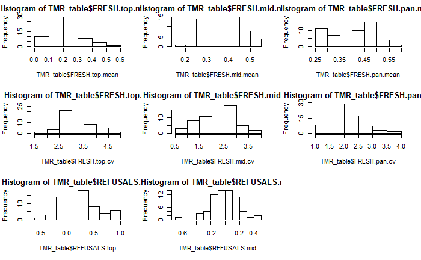

`r`r par(mfrow = c(3,3)) shapiro.test(TMR_table$FRESH.top.mean)

```
    Shapiro-Wilk normality test

data:  TMR_table$FRESH.top.mean
W = 0.95843, p-value = 0.02663
```

`r`r qqnorm(TMR_table$FRESH.top.mean); qqline(TMR_table$FRESH.top.mean) shapiro.test(TMR_table$FRESH.mid.mean)

```
    Shapiro-Wilk normality test

data:  TMR_table$FRESH.mid.mean
W = 0.97166, p-value = 0.1351
```

`r`r qqnorm(TMR_table$FRESH.mid.mean); qqline(TMR_table$FRESH.mid.mean) r shapiro.test(TMR_table$FRESH.pan.mean)

```
    Shapiro-Wilk normality test

data:  TMR_table$FRESH.pan.mean
W = 0.97137, p-value = 0.1304
```

`r`r qqnorm(TMR_table$FRESH.pan.mean); qqline(TMR_table$FRESH.pan.mean) shapiro.test(TMR_table$FRESH.top.cv)

```
    Shapiro-Wilk normality test

data:  TMR_table$FRESH.top.cv
W = 0.96019, p-value = 0.03296
```

`r`r qqnorm(TMR_table$FRESH.top.cv); qqline(TMR_table$FRESH.top.cv) r shapiro.test(TMR_table$FRESH.mid.cv)

```
    Shapiro-Wilk normality test

data:  TMR_table$FRESH.mid.cv
W = 0.98678, p-value = 0.7091
```

`r`r qqnorm(TMR_table$FRESH.mid.cv); qqline(TMR_table$FRESH.mid.cv) shapiro.test(TMR_table$FRESH.pan.cv)

```
    Shapiro-Wilk normality test

data:  TMR_table$FRESH.pan.cv
W = 0.90304, p-value = 8.214e-05
```

`r`r qqnorm(TMR_table$FRESH.pan.cv); qqline(TMR_table$FRESH.pan.cv) r shapiro.test(TMR_table$REFUSALS.top)

```
    Shapiro-Wilk normality test

data:  TMR_table$REFUSALS.top
W = 0.97955, p-value = 0.3464
```

`r`r qqnorm(TMR_table$REFUSALS.top); qqline(TMR_table$REFUSALS.top) shapiro.test(TMR_table$REFUSALS.mid)

```
    Shapiro-Wilk normality test

data:  TMR_table$REFUSALS.mid
W = 0.9762, p-value = 0.2346
```

`r`r qqnorm(TMR_table$REFUSALS.mid); qqline(TMR_table$REFUSALS.mid) r shapiro.test(TMR_table$REFUSALS.pan)

```
    Shapiro-Wilk normality test

data:  TMR_table$REFUSALS.pan
W = 0.94077, p-value = 0.003462
```

`r`r qqnorm(TMR_table$REFUSALS.pan); qqline(TMR_table$REFUSALS.pan)

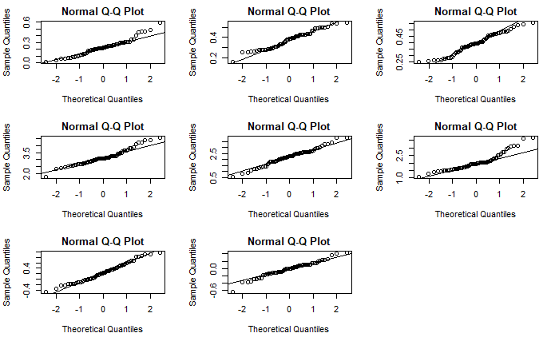

## SURVEY

`r`r ENQ_data <- read.csv2(.csv)

## Making a new matrix with TMR and SURVEY + data manipulation

`r`r DATASET1 <- merge(TMR_table, ENQ_data, by.x = , by.y = , all = FALSE) DATASET1$CONSERVATION_SCORE <- as.factor(DATASET1$CONSERVATION_SCORE) DATASET1$CONSERVATION <- as.factor(DATASET1$CONSERVATION) DATASET1$SPOILAGE <- as.factor(DATASET1$SPOILAGE) DATASET1$SCRAPING_SCORE <- as.factor(DATASET1$SCRAPING_SCORE) DATASET1$SCRAPING <- as.factor(DATASET1$SCRAPING) DATASET1$HOR_VERT_DRUM <- as.factor(DATASET1$HOR_VERT_DRUM) DATASET1$AUGER_SCORE <- as.factor(DATASET1$AUGER_SCORE) DATASET1$AUGER <- as.factor(DATASET1$AUGER) DATASET1$KNIVES_SCORE <- as.factor(DATASET1$KNIVES_SCORE) DATASET1$KNIVES <- as.factor(DATASET1$KNIVES) DATASET1$HAY_PROCESSING <- as.factor(DATASET1$HAY_PROCESSING) DATASET1$POSITION <- as.factor(DATASET1$POSITION) DATASET1$MIXING_START <- as.factor(DATASET1$MIXING_START) DATASET1$MIXING_AFTER_LAST_MIN <- as.factor(DATASET1$MIXING_AFTER_LAST_MIN) DATASET1$MIXING_AFTER_LAST <- as.factor(DATASET1$MIXING_AFTER_LAST) DATASET1$LIQUID <- as.factor(DATASET1$LIQUID) DATASET1$FILLING <- as.factor(DATASET1$FILLING) DATASET1$RPM <- as.factor(DATASET1$RPM) DATASET1$RPM_2 <- as.factor(DATASET1$RPM_2) DATASET1$MOVEMENT_SCORE <- as.factor(DATASET1$MOVEMENT_SCORE) DATASET1$MOVEMENT <- as.factor(DATASET1$MOVEMENT) DATASET1$EMPTY <- as.factor(DATASET1$EMPTY)

`r`r summary(DATASET1)

```
      Herd    FRESH.mid.mean   FRESH.pan.mean   FRESH.top.mean     FRESH.mid.cv
 Herd 1 : 1   Min.   :0.1571   Min.   :0.2523   Min.   :0.01517   Min.   :0.5465
 Herd 10: 1   1st Qu.:0.3063   1st Qu.:0.3364   1st Qu.:0.14807   1st Qu.:1.8130
 Herd 11: 1   Median :0.3883   Median :0.3968   Median :0.21862   Median :2.2506
 Herd 12: 1   Mean   :0.3780   Mean   :0.3962   Mean   :0.22580   Mean   :2.1930
 Herd 13: 1   3rd Qu.:0.4295   3rd Qu.:0.4661   3rd Qu.:0.28076   3rd Qu.:2.6009
 Herd 14: 1   Max.   :0.5444   Max.   :0.5586   Max.   :0.59068   Max.   :3.8025
 (Other):57
  FRESH.pan.cv    FRESH.top.cv    REFUSALS.mid        REFUSALS.pan       REFUSALS.top
 Min.   :1.083   Min.   :1.761   Min.   :-0.632586   Min.   :-0.84947   Min.   :-0.455431
 1st Qu.:1.650   1st Qu.:2.837   1st Qu.:-0.111171   1st Qu.:-0.23013   1st Qu.:-0.005714
 Median :1.945   Median :3.093   Median :-0.003219   Median :-0.16549   Median : 0.229867
 Mean   :2.015   Mean   :3.167   Mean   :-0.014350   Mean   :-0.17404   Mean   : 0.249249
 3rd Qu.:2.134   3rd Qu.:3.445   3rd Qu.: 0.100412   3rd Qu.:-0.06798   3rd Qu.: 0.463900
 Max.   :3.657   Max.   :4.554   Max.   : 0.427621   Max.   : 0.13819   Max.   : 0.961052

 CONSERVATION_SCORE            CONSERVATION         SPOILAGE  SCRAPING_SCORE
 1   : 1            Bad conservation :12    No spoilage :34   1   : 2
 2   : 3            Good conservation:50    Yes spoilage:28   2   :13
 3   : 8            NA's             : 1    NA's        : 1   3   :17
 4   :40                                                      4   :18
 5   :10                                                      5   :12
 NA's: 1                                                      NA's: 1

               SCRAPING     HOR_VERT_DRUM      SIZE      AUGER_SCORE        AUGER
 Not scraped       :32   Horizontal:13    Min.   : 8.0   2   : 8     Auger new :39
 Scraped vertically:30   Vertical  :50    1st Qu.:14.0   3   :10     Auger worn:18
 NA's              : 1                    Median :16.0   4   :27     NA's      : 6
                                          Mean   :17.1   5   :12
                                          3rd Qu.:20.0   NA's: 6
                                          Max.   :30.0
                                          NA's   :2
 KNIVES_SCORE         KNIVES   HAY_PROCESSING          POSITION       MIXING_START
 1   : 6      Knive sharp:29   Hay   :28      Bad position :22   Begin mix  :45
 2   : 6      Knive worn :28   No hay:35      Good position:41   End mix    : 7
 3   :16      NA's       : 6                                     Halfway mix:11
 4   :18
 5   :11
 NA's: 6

 MIXING_AFTER_LAST_MIN                MIXING_AFTER_LAST       LIQUID          FILLING
 7      : 9            Mix after last (<5 min) :23      Liquid   :10   Full       :47
 4      : 7            Mix after last (>9 min) :13      No liquid:53   Overfilled :14
 5      : 7            Mix after last (5-9 min):26                     Underfilled: 2
 2      : 6            NA's                    : 1
 6      : 5
 (Other):28
 NA's   : 1
              RPM                RPM_2    MOVEMENT_SCORE            MOVEMENT
 Fast (20-30)   :32   Fast (>20 rpm):37   2: 4           Little movement:20
 Slow (10-19)   :21   Slow (<20 rpm):25   3:16           Movement       :43
 Very fast (>30): 5   NA's          : 1   4:39
 Very slow (<10): 4                       5: 4
 NA's           : 1


           EMPTY
 Empty mixer  :38
 Remnant mixer:21
 NA's         : 4
```

# Principal Component Analysis TMR

`r`r TMR.pca <- prcomp(na.omit(DATASET1[,2:10]), center = TRUE, scale. = TRUE) print(TMR.pca)

```
Standard deviations (1, .., p=9):
[1] 1.689414e+00 1.510455e+00 1.204156e+00 1.082844e+00 8.792962e-01 5.057031e-01 3.696036e-01
[8] 2.763347e-01 1.001087e-09

Rotation (n x k) = (9 x 9):
                       PC1         PC2         PC3         PC4          PC5          PC6
FRESH.mid.mean -0.39914653 -0.21349813  0.04235691 -0.54924568  0.304156787 -0.139650213
FRESH.pan.mean -0.24940674 -0.29090059  0.20417815  0.63108069 -0.347303986  0.159625497
FRESH.top.mean  0.47362889  0.36458122 -0.17578283 -0.03641854  0.018634324 -0.008672093
FRESH.mid.cv    0.50112658 -0.08855484  0.29405035  0.08637932 -0.081411181 -0.655960091
FRESH.pan.cv    0.45364895 -0.15186682  0.32708155 -0.24199672 -0.006226992  0.707497586
FRESH.top.cv    0.07113749 -0.48958699  0.46637830 -0.24642397 -0.128124655 -0.149062453
REFUSALS.mid   -0.23269652  0.34886481  0.18476811 -0.32128944 -0.690485621 -0.039830497
REFUSALS.pan   -0.16057424  0.27150699  0.54187724  0.25674274  0.534302053  0.005693135
REFUSALS.top    0.11061858 -0.52043474 -0.43230857  0.05336399  0.034493381 -0.016350627
                       PC7          PC8           PC9
FRESH.mid.mean  0.04311547  0.327719121  5.199648e-01
FRESH.pan.mean  0.07484956  0.136621185  4.928016e-01
FRESH.top.mean -0.08500019 -0.340733900  6.976985e-01
FRESH.mid.cv   -0.01967081  0.458044569 -1.394697e-10
FRESH.pan.cv   -0.05200803  0.319840431  1.133877e-10
FRESH.top.cv    0.06568674 -0.658832492 -1.535350e-10
REFUSALS.mid   -0.45190650  0.064831865  9.228091e-11
REFUSALS.pan   -0.49797455 -0.086384845  1.138825e-10
REFUSALS.top   -0.72505787 -0.002597283  3.365144e-11
```

`r`r PREDICT_PCA <- as.data.frame(predict(TMR.pca))

`r`r plot(TMR.pca, type = )

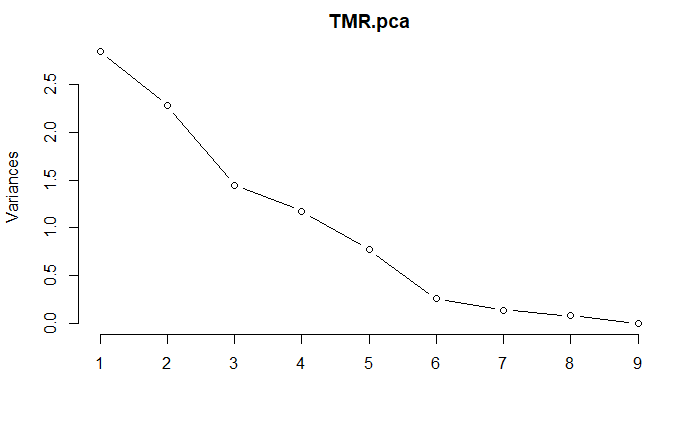

`r`r summary(TMR.pca)

```
Importance of components:
                          PC1    PC2    PC3    PC4     PC5     PC6     PC7     PC8       PC9
Standard deviation     1.6894 1.5105 1.2042 1.0828 0.87930 0.50570 0.36960 0.27633 1.001e-09
Proportion of Variance 0.3171 0.2535 0.1611 0.1303 0.08591 0.02842 0.01518 0.00848 0.000e+00
Cumulative Proportion  0.3171 0.5706 0.7317 0.8620 0.94792 0.97634 0.99152 1.00000 1.000e+00
```

`r`r biplot(TMR.pca)

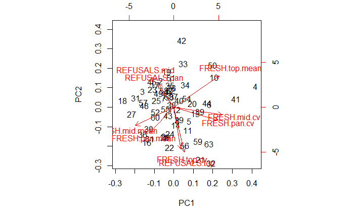

`r`r fviz_pca_var(TMR.pca, col.var = )

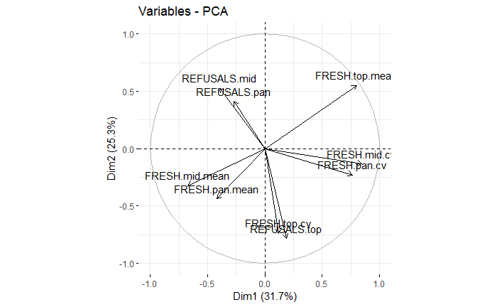

# Regression Tree TMR + SURVEY

## PC1

`r`r fit <- rpart(PREDICT_PCA$PC1 ~ SPOILAGE + SCRAPING + HOR_VERT_DRUM + AUGER + KNIVES + HAY_PROCESSING + POSITION + MIXING_START + MIXING_AFTER_LAST + LIQUID + FILLING + RPM_2 + MOVEMENT + EMPTY, data = DATASET1, method=) printcp(fit) # display the results

```
Regression tree:
rpart(formula = PREDICT_PCA$PC1 ~ SPOILAGE + SCRAPING + HOR_VERT_DRUM +
    AUGER + KNIVES + HAY_PROCESSING + POSITION + MIXING_START +
    MIXING_AFTER_LAST + LIQUID + FILLING + RPM_2 + MOVEMENT +
    EMPTY, data = DATASET1, method = \anova\)

Variables actually used in tree construction:
[1] FILLING           MIXING_AFTER_LAST POSITION          RPM_2

Root node error: 176.96/63 = 2.8088

n= 63

        CP nsplit rel error xerror    xstd
1 0.062608      0   1.00000 1.0280 0.21920
2 0.015942      2   0.87478 1.1752 0.24912
3 0.010000      4   0.84290 1.2654 0.26398
```

`r`r plotcp(fit) # visualize cross-validation results

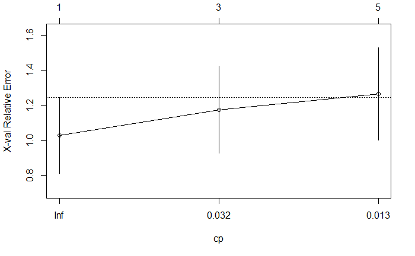

`r`r summary(fit) # detailed summary of splits

```
Call:
rpart(formula = PREDICT_PCA$PC1 ~ SPOILAGE + SCRAPING + HOR_VERT_DRUM +
    AUGER + KNIVES + HAY_PROCESSING + POSITION + MIXING_START +
    MIXING_AFTER_LAST + LIQUID + FILLING + RPM_2 + MOVEMENT +
    EMPTY, data = DATASET1, method = \anova\)
  n= 63

          CP nsplit rel error   xerror      xstd
1 0.06260792      0 1.0000000 1.027990 0.2192030
2 0.01594223      2 0.8747842 1.175218 0.2491244
3 0.01000000      4 0.8428997 1.265368 0.2639827

Variable importance
            RPM_2          POSITION MIXING_AFTER_LAST           FILLING            LIQUID
               33                31                 9                 7                 7
     MIXING_START     HOR_VERT_DRUM          SCRAPING          MOVEMENT
                4                 3                 3                 2

Node number 1: 63 observations,    complexity param=0.06260792
  mean=-3.313046e-16, MSE=2.808815
  left son=2 (41 obs) right son=3 (22 obs)
  Primary splits:
      POSITION     splits as  RL,  improve=0.06113871, (0 missing)
      LIQUID       splits as  LR,  improve=0.04841654, (0 missing)
      SPOILAGE     splits as  LR,  improve=0.04625282, (1 missing)
      MIXING_START splits as  LRL, improve=0.02505020, (0 missing)
      RPM_2        splits as  RL,  improve=0.02424322, (1 missing)

Node number 2: 41 observations,    complexity param=0.01594223
  mean=-0.3035562, MSE=2.415466
  left son=4 (29 obs) right son=5 (12 obs)
  Primary splits:
      FILLING           splits as  LRR, improve=0.024569920, (0 missing)
      SPOILAGE          splits as  LR,  improve=0.018256510, (1 missing)
      MIXING_AFTER_LAST splits as  LRL, improve=0.014128440, (0 missing)
      EMPTY             splits as  RL,  improve=0.006696309, (2 missing)
      AUGER             splits as  RL,  improve=0.002751910, (4 missing)
  Surrogate splits:
      MOVEMENT     splits as  RL,  agree=0.780, adj=0.250, (0 split)
      MIXING_START splits as  LLR, agree=0.756, adj=0.167, (0 split)
```

[output cut: 25 more lines]

```

Node number 5: 12 observations
  mean=0.07515724, MSE=4.926652

Node number 6: 10 observations
  mean=-0.2207163, MSE=2.581329

Node number 7: 12 observations
  mean=1.221081, MSE=2.495861

Node number 8: 22 observations
  mean=-0.6479004, MSE=1.111587

Node number 9: 7 observations
  mean=0.1294455, MSE=1.402463
```

`r`r # plot tree fancyRpartPlot(fit)

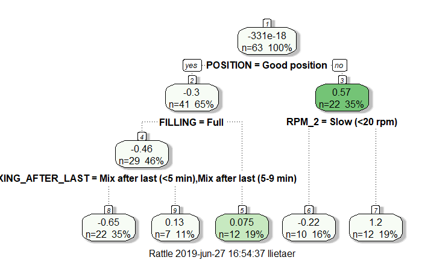

## PC2

`r`r fit <- rpart(PREDICT_PCA$PC2 ~ SPOILAGE + SCRAPING + HOR_VERT_DRUM + AUGER + KNIVES + HAY_PROCESSING + POSITION + MIXING_START + MIXING_AFTER_LAST + LIQUID + FILLING + RPM_2 + MOVEMENT + EMPTY, data = DATASET1, method=) printcp(fit) # display the results

```
Regression tree:
rpart(formula = PREDICT_PCA$PC2 ~ SPOILAGE + SCRAPING + HOR_VERT_DRUM +
    AUGER + KNIVES + HAY_PROCESSING + POSITION + MIXING_START +
    MIXING_AFTER_LAST + LIQUID + FILLING + RPM_2 + MOVEMENT +
    EMPTY, data = DATASET1, method = \anova\)

Variables actually used in tree construction:
[1] HAY_PROCESSING    HOR_VERT_DRUM     MIXING_AFTER_LAST SPOILAGE

Root node error: 141.45/63 = 2.2453

n= 63

        CP nsplit rel error  xerror    xstd
1 0.203115      0   1.00000 1.02970 0.18018
2 0.065804      1   0.79688 0.89121 0.14493
3 0.045003      2   0.73108 0.90570 0.14846
4 0.012389      3   0.68608 0.90983 0.16765
5 0.010000      4   0.67369 0.95223 0.17520
```

`r`r plotcp(fit) # visualize cross-validation results

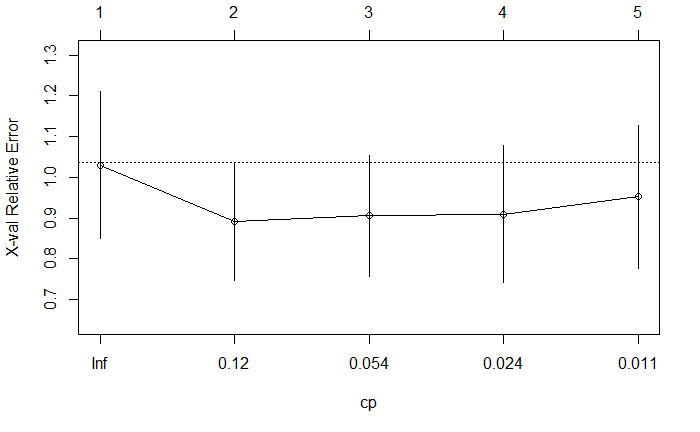

`r`r summary(fit) # detailed summary of splits

```
Call:
rpart(formula = PREDICT_PCA$PC2 ~ SPOILAGE + SCRAPING + HOR_VERT_DRUM +
    AUGER + KNIVES + HAY_PROCESSING + POSITION + MIXING_START +
    MIXING_AFTER_LAST + LIQUID + FILLING + RPM_2 + MOVEMENT +
    EMPTY, data = DATASET1, method = \anova\)
  n= 63

          CP nsplit rel error    xerror      xstd
1 0.20311544      0 1.0000000 1.0296950 0.1801841
2 0.06580422      1 0.7968846 0.8912115 0.1449255
3 0.04500310      2 0.7310803 0.9056999 0.1484551
4 0.01238903      3 0.6860772 0.9098250 0.1676488
5 0.01000000      4 0.6736882 0.9522279 0.1751987

Variable importance
         SPOILAGE          SCRAPING     HOR_VERT_DRUM MIXING_AFTER_LAST      MIXING_START
               44                16                15                10                 5
         POSITION    HAY_PROCESSING            LIQUID           FILLING
                5                 3                 2                 1

Node number 1: 63 observations,    complexity param=0.2031154
  mean=1.198336e-16, MSE=2.24526
  left son=2 (28 obs) right son=3 (35 obs)
  Primary splits:
      SPOILAGE          splits as  RL,  improve=0.19723230, (1 missing)
      MIXING_START      splits as  RLR, improve=0.06034323, (0 missing)
      HOR_VERT_DRUM     splits as  LR,  improve=0.04486213, (0 missing)
      MIXING_AFTER_LAST splits as  LLR, improve=0.03026146, (1 missing)
      HAY_PROCESSING    splits as  RL,  improve=0.02905329, (0 missing)
  Surrogate splits:
      SCRAPING     splits as  LR,  agree=0.710, adj=0.357, (0 split)
      POSITION     splits as  LR,  agree=0.581, adj=0.071, (1 split)
      MIXING_START splits as  RLR, agree=0.565, adj=0.036, (0 split)
      LIQUID       splits as  LR,  agree=0.565, adj=0.036, (0 split)

Node number 2: 28 observations,    complexity param=0.0450031
  mean=-0.7550224, MSE=1.744285
  left son=4 (16 obs) right son=5 (12 obs)
  Primary splits:
      MIXING_AFTER_LAST splits as  LLR, improve=0.130339000, (0 missing)
```

[output cut: 32 more lines]

```
      HAY_PROCESSING splits as  RL,  improve=0.05113304, (0 missing)
      POSITION       splits as  RL,  improve=0.04758470, (0 missing)
      MOVEMENT       splits as  LR,  improve=0.03396459, (0 missing)
      SCRAPING       splits as  RL,  improve=0.03106525, (1 missing)
      FILLING        splits as  RLL, improve=0.01460682, (0 missing)
  Surrogate splits:
      SCRAPING          splits as  RL,  agree=0.630, adj=0.167, (0 split)
      MIXING_AFTER_LAST splits as  LLR, agree=0.593, adj=0.083, (0 split)
      FILLING           splits as  LRL, agree=0.593, adj=0.083, (0 split)

Node number 14: 15 observations
  mean=0.6568599, MSE=0.9604078

Node number 15: 12 observations
  mean=1.169565, MSE=1.509477
```

`r`r # plot tree fancyRpartPlot(fit)

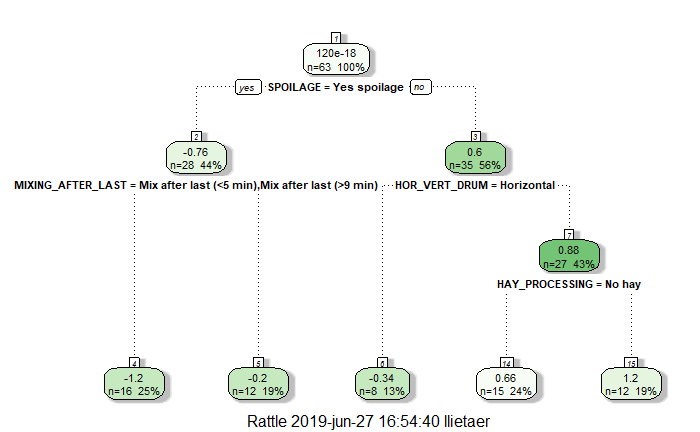

# Factor Analysis of Mixed Data TMR + SURVEY

`r`r datafamd <- na.omit(DATASET1[,c(2:10, ## TMRaudit active 13,16,22,23,26, ## active categorical variables 15,19,21,24,27,28,30,32,33 ## supplementary categorical variables )]) datafamd$FRESH.top.mean <- scale((datafamd$FRESH.top.mean), center = TRUE, scale = TRUE) datafamd$FRESH.mid.mean <- scale((datafamd$FRESH.mid.mean), center = TRUE, scale = TRUE) datafamd$FRESH.pan.mean <- scale((datafamd$FRESH.pan.mean), center = TRUE, scale = TRUE) datafamd$FRESH.top.cv <- scale((datafamd$FRESH.top.cv), center = TRUE, scale = TRUE) datafamd$FRESH.mid.cv <- scale((datafamd$FRESH.mid.cv), center = TRUE, scale = TRUE) datafamd$FRESH.pan.cv <- scale((datafamd$FRESH.pan.cv), center = TRUE, scale = TRUE) datafamd$REFUSALS.top <- scale((datafamd$REFUSALS.top), center = TRUE, scale = TRUE) datafamd$REFUSALS.mid <- scale((datafamd$REFUSALS.mid), center = TRUE, scale = TRUE) datafamd$REFUSALS.pan <- scale((datafamd$REFUSALS.pan), center = TRUE, scale = TRUE) summary(datafamd)

```
  FRESH.mid.mean.V1    FRESH.pan.mean.V1    FRESH.top.mean.V1     FRESH.mid.cv.V1
 Min.   :-2.5980999   Min.   :-1.5582386   Min.   :-1.8578091   Min.   :-2.1892416
 1st Qu.:-0.9834333   1st Qu.:-0.7336327   1st Qu.:-0.4798073   1st Qu.:-0.6410230
 Median : 0.1586527   Median : 0.0086126   Median :-0.1406580   Median : 0.0289515
 Mean   : 0.0000000   Mean   : 0.0000000   Mean   : 0.0000000   Mean   : 0.0000000
 3rd Qu.: 0.6295261   3rd Qu.: 0.6092112   3rd Qu.: 0.4655080   3rd Qu.: 0.5505385
 Max.   : 1.8706141   Max.   : 2.0408219   Max.   : 2.9473553   Max.   : 2.4120249
   FRESH.pan.cv.V1      FRESH.top.cv.V1      REFUSALS.mid.V1     REFUSALS.pan.V1
 Min.   :-1.7634903   Min.   :-2.5084628   Min.   :-3.194632   Min.   :-2.4773000
 1st Qu.:-0.6552397   1st Qu.:-0.5781321   1st Qu.:-0.458329   1st Qu.:-0.3862120
 Median :-0.2240323   Median :-0.1511531   Median : 0.130968   Median : 0.0032068
 Mean   : 0.0000000   Mean   : 0.0000000   Mean   : 0.000000   Mean   : 0.0000000
 3rd Qu.: 0.3230163   3rd Qu.: 0.4655137   3rd Qu.: 0.675260   3rd Qu.: 0.6512748
 Max.   : 2.8296061   Max.   : 2.5579657   Max.   : 2.334802   Max.   : 1.9557822
   REFUSALS.top.V1            SPOILAGE     HOR_VERT_DRUM HAY_PROCESSING          POSITION
 Min.   :-1.8009533   No spoilage :27   Horizontal: 5    Hay   :23      Bad position :16
 1st Qu.:-0.7697309   Yes spoilage:23   Vertical  :45    No hay:27      Good position:34
 Median :-0.1317794
 Mean   : 0.0000000
 3rd Qu.: 0.6463161
 Max.   : 2.1941079
                MIXING_AFTER_LAST               SCRAPING         AUGER            KNIVES
 Mix after last (<5 min) :19      Not scraped       :25   Auger new :37   Knive sharp:25
 Mix after last (>9 min) :11      Scraped vertically:25   Auger worn:13   Knive worn :25
 Mix after last (5-9 min):20



      MIXING_START       LIQUID          FILLING              RPM_2               MOVEMENT
 Begin mix  :36    Liquid   : 9   Full       :37   Fast (>20 rpm):34   Little movement:15
 End mix    : 5    No liquid:41   Overfilled :11   Slow (<20 rpm):16   Movement       :35
 Halfway mix: 9                   Underfilled: 2



           EMPTY
 Empty mixer  :33
 Remnant mixer:17
```

`r`r res.mfa <- FAMD(datafamd, graph=TRUE, sup.var=c(15:23))

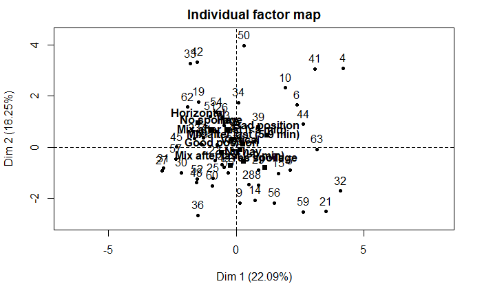

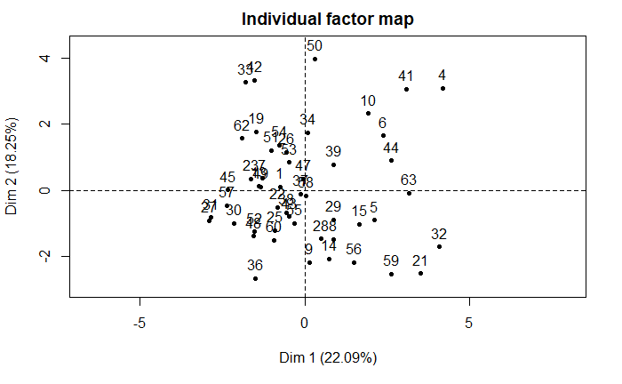

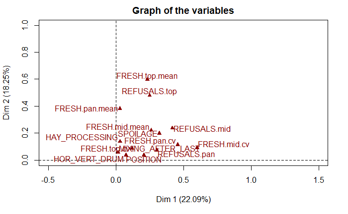

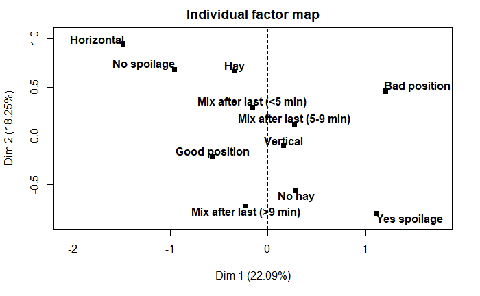

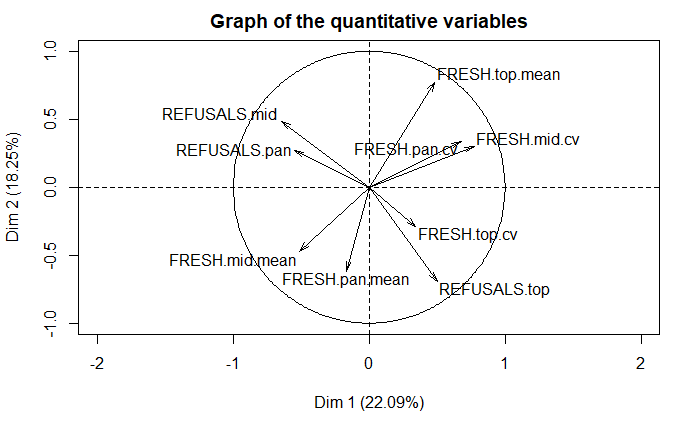

`r`r print(res.mfa)

```
*The results are available in the following objects:

  name          description
1 \$eig\        \eigenvalues and inertia\
2 \$var\        \Results for the variables\
3 \$ind\        \results for the individuals\
4 \$quali.var\  \Results for the qualitative variables\
5 \$quanti.var\ \Results for the quantitative variables\
```

`r`r eig.val <- get_eigenvalue(res.mfa) head(eig.val)

```
      eigenvalue variance.percent cumulative.variance.percent
Dim.1   3.313406        22.089372                    22.08937
Dim.2   2.737714        18.251424                    40.34080
Dim.3   2.097188        13.981250                    54.32205
Dim.4   1.308376         8.722503                    63.04455
Dim.5   1.155183         7.701223                    70.74577
```

## visualisations

`r`r fviz_screeplot(res.mfa)

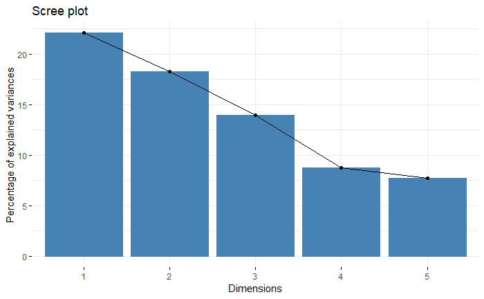

`r`r # Contribution to the first dimension fviz_contrib(res.mfa, , axes = 1)

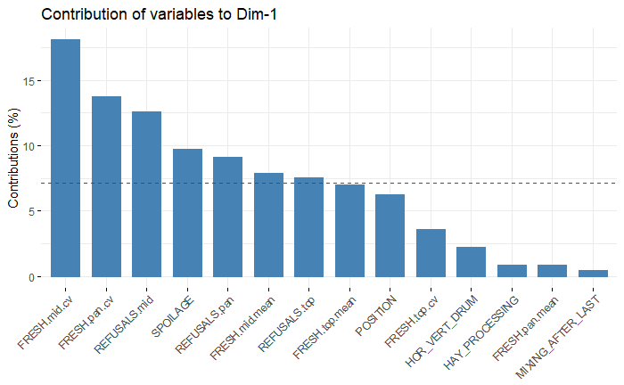

`r`r # Contribution to the second dimension fviz_contrib(res.mfa, , axes = 2)

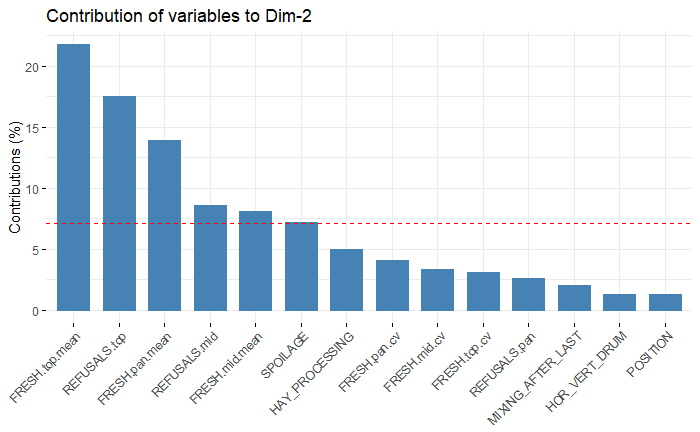

`r`r quanti.var <- get_famd_var(res.mfa, .var) quanti.var

```
FAMD results for quantitative variables
 ===================================================
  Name       Description
1 \$coord\   \Coordinates\
2 \$cos2\    \Cos2
```

`r`r fviz_famd_var(res.mfa, .var, col.var = , gradient.cols = c(#00AFBB, #E7B800, #FC4E07), repel = TRUE)

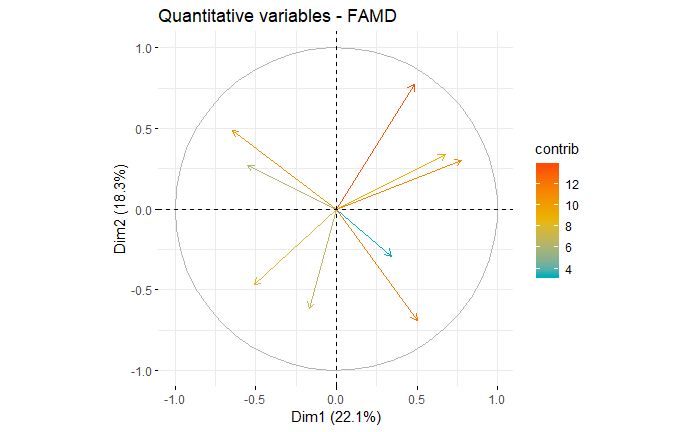

`r`r p <- fviz_famd_var(res.mfa, .var, label=, col.var = ) p

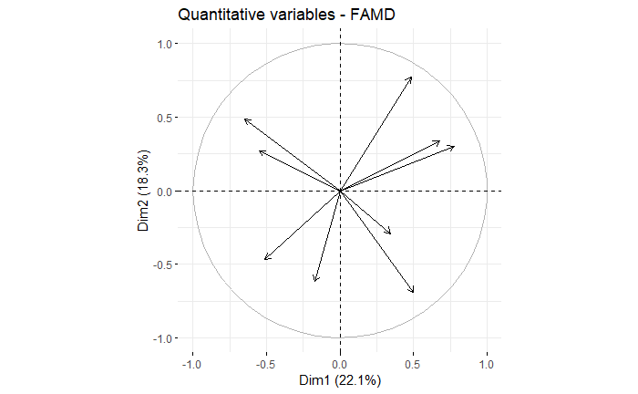

`r`r p + annotate(, x=.7, y=1.1, label=expression([TOP.MEAN]), size=3, angle=60) + annotate(, x=1, y=.5, label=expression([PAN.CV]), size=3, angle=30) + annotate(, x=1.1, y=.45, label=expression([MID.CV]), size=3, angle=25) + annotate(, x=.65, y=-.45, label=expression([TOP.CV]), size=3, angle=330) + annotate(, x=.75, y=-1, label=expression([TOP]), size=3, angle=310) + annotate(, x=-.3, y=-1, label=expression([PAN.MEAN]), size=3, angle=76) + annotate(, x=-0.8, y=-.65, label=expression([MID.MEAN]), size=3, angle=40) + annotate(, x=-.9, y=0.40, label=expression([PAN]), size=3, angle=340) + annotate(, x=-.95, y=0.7, label=expression([MID]), size=3, angle=330) + expand_limits(x=c(-1.5,1.5), y=c(-1.5,1.5))

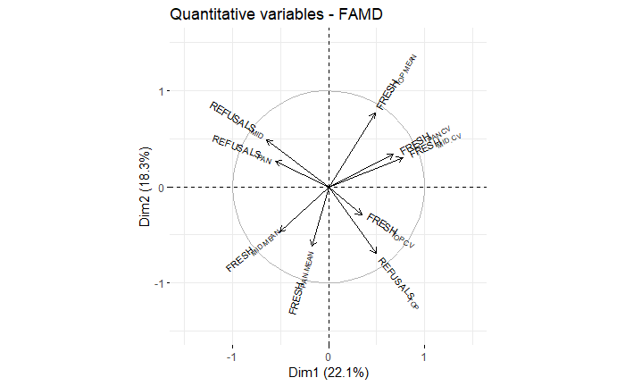

`r`r quali.var <- get_famd_var(res.mfa, .var) quali.var

```
FAMD results for qualitative variable categories
 ===================================================
  Name       Description
1 \$coord\   \Coordinates\
2 \$cos2\    \Cos2
```

`r`r plot(res.mfa, choix = )

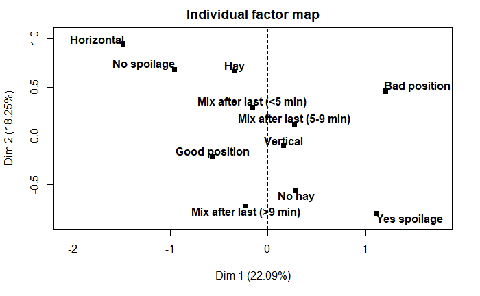

`r`r fviz_famd_var(res.mfa, .var, repel = TRUE, col.var = )

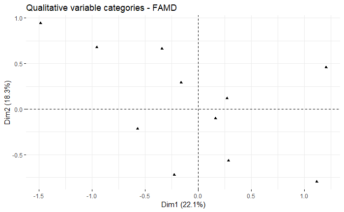

`r`r fviz_famd_ind(res.mfa, col.ind = 2, geom=c(, ), gradient.cols = c(#00AFBB, #E7B800, #FC4E07), repel = TRUE, invisible = .var)

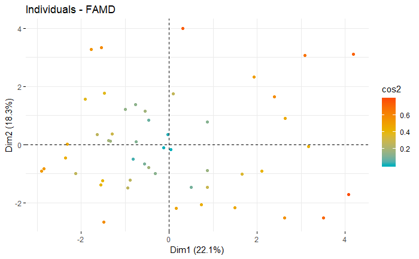

`r`r fviz_ellipses(res.mfa, c(, , _VERT_DRUM, _PROCESSING, _AFTER_LAST), repel = TRUE)

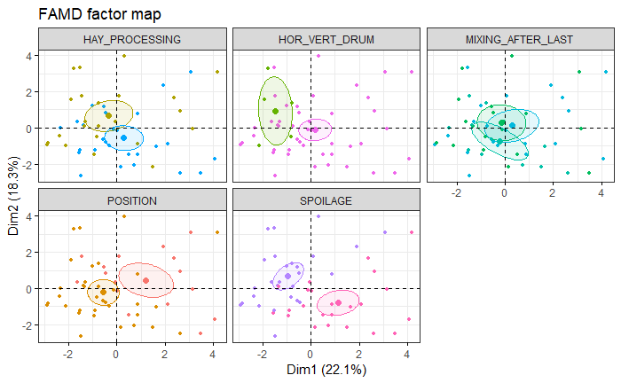

# MPR + ENQ

## Making a new matrix with MPR and SELECTED SURVEY VARIABLES

`r`r MPR <- read.csv2(_data.csv) summary(MPR)

```
      HERD         COWS             DIM            KGMILK           FPCM            FAT
 Herd 1 : 1   Min.   : 47.00   Min.   :126.0   Min.   :24.80   Min.   :25.37   Min.   :37.70
 Herd 10: 1   1st Qu.: 83.25   1st Qu.:164.2   1st Qu.:29.20   1st Qu.:30.46   1st Qu.:41.25
 Herd 11: 1   Median :126.50   Median :173.5   Median :30.85   Median :32.30   Median :42.40
 Herd 12: 1   Mean   :154.63   Mean   :175.8   Mean   :30.90   Mean   :32.28   Mean   :42.86
 Herd 14: 1   3rd Qu.:189.00   3rd Qu.:189.8   3rd Qu.:32.27   3rd Qu.:33.77   3rd Qu.:44.50
 Herd 15: 1   Max.   :536.00   Max.   :235.0   Max.   :40.10   Max.   :40.35   Max.   :54.10
 (Other):48
    PROTEIN           KGFP            AGE           AGE_YEAR
 Min.   :32.90   Min.   :1.600   Min.   :3.010   Min.   :3.083
 1st Qu.:34.52   1st Qu.:2.300   1st Qu.:3.050   1st Qu.:3.417
 Median :35.35   Median :2.400   Median :3.065   Median :3.542
 Mean   :35.35   Mean   :2.404   Mean   :3.207   Mean   :3.595
 3rd Qu.:36.08   3rd Qu.:2.500   3rd Qu.:3.090   3rd Qu.:3.750
 Max.   :39.00   Max.   :3.000   Max.   :4.050   Max.   :4.417
                                 NA's   :2       NA's   :2
```

`r`r sd(MPR$COWS)

```
[1] 105.9586
```

`r`r sd(MPR$DIM)

```
[1] 22.50205
```

`r`r sd(MPR$KGMILK)

```
[1] 3.070584
```

`r`r sd(MPR$FPCM)

```
[1] 2.806805
```

`r`r sd(MPR$FAT)

```
[1] 2.894573
```

`r`r sd(MPR$PROTEIN)

```
[1] 1.144097
```

`r`r sd(MPR$KGFP)

```
[1] 0.2206021
```

`r`r sd(na.omit(MPR$AGE_YEAR))

```
[1] 0.290568
```

`r`r par(mfrow = c(3,3)) hist(MPR$DIM) hist(MPR$KGMILK) r hist(MPR$FPCM) hist(MPR$FAT) r hist(MPR$PROTEIN) hist(MPR$KGFP) r hist(MPR$AGE_YEAR)

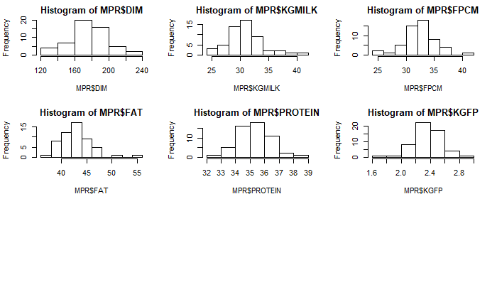

`r`r par(mfrow = c(3,3)) shapiro.test(MPR$DIM)

```
    Shapiro-Wilk normality test

data:  MPR$DIM
W = 0.98634, p-value = 0.7934
```

`r`r qqnorm(MPR$DIM); qqline(MPR$DIM) shapiro.test(MPR$KGMILK)

```
    Shapiro-Wilk normality test

data:  MPR$KGMILK
W = 0.96285, p-value = 0.09244
```

`r`r qqnorm(MPR$KGMILK); qqline(MPR$KGMILK) r shapiro.test(MPR$FPCM)

```
    Shapiro-Wilk normality test

data:  MPR$FPCM
W = 0.96949, p-value = 0.1831
```

`r`r qqnorm(MPR$FPCM); qqline(MPR$FPCM) shapiro.test(MPR$FAT)

```
    Shapiro-Wilk normality test

data:  MPR$FAT
W = 0.91816, p-value = 0.001273
```

`r`r qqnorm(MPR$FAT); qqline(MPR$FAT) r shapiro.test(MPR$PROTEIN)

```
    Shapiro-Wilk normality test

data:  MPR$PROTEIN
W = 0.97826, p-value = 0.4293
```

`r`r qqnorm(MPR$PROTEIN); qqline(MPR$PROTEIN) shapiro.test(MPR$KGFP)

```
    Shapiro-Wilk normality test

data:  MPR$KGFP
W = 0.93177, p-value = 0.004293
```

`r`r qqnorm(MPR$KGFP); qqline(MPR$KGFP) r shapiro.test(MPR$AGE_YEAR)

```
    Shapiro-Wilk normality test

data:  MPR$AGE_YEAR
W = 0.9672, p-value = 0.1604
```

`r`r qqnorm(MPR$AGE_YEAR); qqline(MPR$AGE_YEAR)

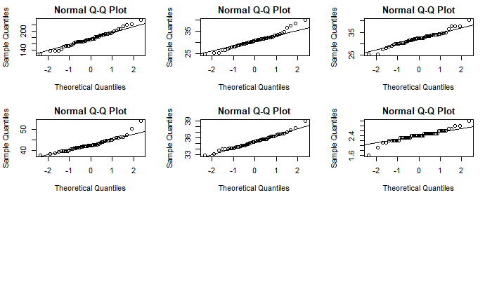

`r`r DATASET2 <- merge(MPR, DATASET1, by.x= ‘HERD’, by.y= , all = FALSE) summary(DATASET2)

```
      HERD         COWS            DIM            KGMILK           FPCM            FAT
 Herd 1 : 1   Min.   : 47.0   Min.   :126.0   Min.   :24.80   Min.   :25.37   Min.   :37.70
 Herd 10: 1   1st Qu.: 83.5   1st Qu.:164.0   1st Qu.:29.30   1st Qu.:30.55   1st Qu.:41.30
 Herd 11: 1   Median :123.0   Median :173.0   Median :31.00   Median :32.34   Median :42.40
 Herd 12: 1   Mean   :147.3   Mean   :175.0   Mean   :31.05   Mean   :32.37   Mean   :42.67
 Herd 14: 1   3rd Qu.:184.0   3rd Qu.:188.5   3rd Qu.:32.25   3rd Qu.:33.92   3rd Qu.:44.35
 Herd 15: 1   Max.   :536.0   Max.   :235.0   Max.   :40.10   Max.   :40.35   Max.   :50.40
 (Other):45
    PROTEIN           KGFP            AGE           AGE_YEAR     FRESH.mid.mean
 Min.   :32.90   Min.   :1.600   Min.   :3.010   Min.   :3.083   Min.   :0.1571
 1st Qu.:34.45   1st Qu.:2.300   1st Qu.:3.050   1st Qu.:3.417   1st Qu.:0.3088
 Median :35.30   Median :2.400   Median :3.070   Median :3.583   Median :0.3910
 Mean   :35.28   Mean   :2.408   Mean   :3.217   Mean   :3.609   Mean   :0.3812
 3rd Qu.:35.90   3rd Qu.:2.500   3rd Qu.:3.090   3rd Qu.:3.750   3rd Qu.:0.4370
 Max.   :37.70   Max.   :3.000   Max.   :4.050   Max.   :4.417   Max.   :0.5444
                                 NA's   :2       NA's   :2
 FRESH.pan.mean   FRESH.top.mean     FRESH.mid.cv     FRESH.pan.cv    FRESH.top.cv
 Min.   :0.2523   Min.   :0.01517   Min.   :0.8072   Min.   :1.083   Min.   :1.761
 1st Qu.:0.3364   1st Qu.:0.14807   1st Qu.:1.8130   1st Qu.:1.670   1st Qu.:2.880
 Median :0.3968   Median :0.21734   Median :2.2893   Median :1.942   Median :3.114
 Mean   :0.3949   Mean   :0.22386   Mean   :2.2114   Mean   :2.036   Mean   :3.219
 3rd Qu.:0.4616   3rd Qu.:0.27465   3rd Qu.:2.6009   3rd Qu.:2.133   3rd Qu.:3.556
 Max.   :0.5586   Max.   :0.59068   Max.   :3.8025   Max.   :3.657   Max.   :4.554

  REFUSALS.mid         REFUSALS.pan      REFUSALS.top      CONSERVATION_SCORE
 Min.   :-0.3719836   Min.   :-0.8495   Min.   :-0.45543   1   : 1
 1st Qu.:-0.1111710   1st Qu.:-0.2301   1st Qu.: 0.03289   2   : 3
 Median : 0.0008292   Median :-0.1727   Median : 0.25692   3   : 7
 Mean   :-0.0049886   Mean   :-0.1845   Mean   : 0.26195   4   :32
 3rd Qu.: 0.0988444   3rd Qu.:-0.0979   3rd Qu.: 0.46390   5   : 7
 Max.   : 0.4276215   Max.   : 0.1382   Max.   : 0.90425   NA's: 1

            CONSERVATION         SPOILAGE  SCRAPING_SCORE               SCRAPING
 Bad conservation :11    No spoilage :27   1   : 2        Not scraped       :26
 Good conservation:39    Yes spoilage:23   2   :13        Scraped vertically:24
 NA's             : 1    NA's        : 1   3   :11        NA's              : 1
                                           4   :16
                                           5   : 8
                                           NA's: 1

```

[output cut: 14 more lines]

```
                                                     (Other):24
                                                     NA's   : 1
                MIXING_AFTER_LAST       LIQUID          FILLING                RPM
 Mix after last (<5 min) :17      Liquid   : 7   Full       :37   Fast (20-30)   :26
 Mix after last (>9 min) :10      No liquid:44   Overfilled :12   Slow (10-19)   :17
 Mix after last (5-9 min):23                     Underfilled: 2   Very fast (>30): 4
 NA's                    : 1                                      Very slow (<10): 3
                                                                  NA's           : 1


            RPM_2    MOVEMENT_SCORE            MOVEMENT            EMPTY
 Fast (>20 rpm):30   2: 4           Little movement:15   Empty mixer  :34
 Slow (<20 rpm):20   3:11           Movement       :36   Remnant mixer:15
 NA's          : 1   4:32                                NA's         : 2
                     5: 4
```

`r`r sd(DATASET2$COWS)

```
[1] 93.34342
```

`r`r sd(DATASET2$DIM)

```
[1] 22.7306
```

`r`r sd(DATASET2$KGMILK)

```
[1] 3.000887
```

`r`r sd(DATASET2$FPCM)

```
[1] 2.806381
```

`r`r sd(DATASET2$FAT)

```
[1] 2.451992
```

`r`r sd(DATASET2$PROTEIN)

```
[1] 1.042226
```

`r`r sd(DATASET2$KGFP)

```
[1] 0.2225697
```

`r`r sd(na.omit(DATASET2$AGE_YEAR))

```
[1] 0.2932505
```

`r`r DATASET2.pca <- prcomp(na.omit(DATASET2[,c(2:8,10,11:19)]), center = TRUE, scale. = TRUE) print(DATASET2.pca)

```
Standard deviations (1, .., p=17):
 [1] 1.905473e+00 1.663731e+00 1.574398e+00 1.423346e+00 1.192109e+00 9.917348e-01 9.343735e-01
 [8] 9.282026e-01 8.176796e-01 7.250504e-01 5.616012e-01 5.280598e-01 3.050471e-01 2.471871e-01
[15] 1.197673e-01 1.461375e-02 1.002187e-09

Rotation (n x k) = (17 x 17):
                       PC1          PC2         PC3         PC4         PC5          PC6
COWS            0.06066605  0.279428093  0.26998333  0.24805505  0.08140368 -0.107420392
DIM             0.17681248  0.113830893  0.01927807 -0.19847863 -0.25775955 -0.686552080
KGMILK         -0.49713387 -0.007468185 -0.09277683  0.07213851 -0.06987035 -0.121857159
FPCM           -0.49307279 -0.083227192 -0.05846304 -0.08067383  0.03967779 -0.143554220
FAT             0.13840968 -0.241007701  0.08714745 -0.40829613  0.32073680  0.030041430
PROTEIN         0.23316857  0.052896385  0.20527954 -0.30793234  0.14143719 -0.334514504
KGFP           -0.48205179 -0.070383334 -0.04889994 -0.13462277  0.04892607 -0.161728571
AGE_YEAR       -0.15192943 -0.269475280 -0.10633759  0.17604983  0.41623744  0.009999006
FRESH.mid.mean -0.20708952  0.173078570  0.28662644 -0.33332956  0.28689524 -0.016355708
FRESH.pan.mean -0.03225959  0.355280422  0.15007231  0.28831989 -0.21548999  0.142672932
FRESH.top.mean  0.19428480 -0.414473728 -0.34985180  0.05146520 -0.06937789 -0.096162131
FRESH.mid.cv    0.17802890  0.147580650 -0.47061685  0.13111539  0.23078196  0.011276263
FRESH.pan.cv    0.09664469  0.239639965 -0.38703404 -0.12461816  0.33795856 -0.010432200
FRESH.top.cv   -0.02586286  0.506631423 -0.09303918 -0.14114739  0.30223432  0.168919141
REFUSALS.mid    0.06021433 -0.216131468  0.35936276 -0.13817800  0.01982244  0.391285312
REFUSALS.pan   -0.02428210  0.004155577  0.17565705  0.46363137  0.36067840 -0.344889416
REFUSALS.top   -0.13498413  0.230097302 -0.29030517 -0.30519085 -0.31478801  0.109081491
                        PC7         PC8         PC9        PC10        PC11         PC12
COWS            0.290953735 -0.02667174 -0.65896228 -0.18379163  0.43121624  0.062107108
DIM             0.054193387  0.22779439  0.26315514 -0.44284255  0.04607183  0.226053757
KGMILK          0.102503711  0.19768046 -0.04486059  0.06447547 -0.02870944  0.002742564
FPCM           -0.035352962  0.19628481 -0.07055725  0.11974625  0.12536620  0.061051639
FAT            -0.381097973 -0.10032845  0.04033881  0.05315903  0.60140909  0.211414156
PROTEIN        -0.311456773  0.18234682 -0.42705174  0.31089252 -0.42841193 -0.226578045
KGFP           -0.093495036  0.19199858 -0.11043982  0.13057178  0.12345229  0.039434702
AGE_YEAR       -0.291142225 -0.05887681 -0.19811406 -0.68657725 -0.28959858 -0.008938901
FRESH.mid.mean  0.322940291 -0.32344450  0.15161067 -0.05856808 -0.16799592  0.107497214
FRESH.pan.mean -0.553221836  0.25409490  0.07155856 -0.05282528  0.12572889 -0.033865934
FRESH.top.mean  0.160441736  0.06965308 -0.17904759  0.08850275  0.04097434 -0.061988908
FRESH.mid.cv   -0.003988469  0.16193910 -0.06004489  0.16897826 -0.08749495  0.629356174
FRESH.pan.cv    0.155777400  0.27269785  0.15408931 -0.11904837  0.25995153 -0.623273971
FRESH.top.cv    0.016175078  0.15150428  0.02645172  0.01266247 -0.15834187  0.160915688
REFUSALS.mid    0.125274628  0.57181433  0.12182296 -0.17684292 -0.04430135  0.088848622
REFUSALS.pan   -0.142115415 -0.16845963  0.37502388  0.19922560  0.05070135 -0.076213948
REFUSALS.top   -0.261505275 -0.36499676 -0.10190165 -0.18919114  0.02251020 -0.054200654
                       PC13          PC14          PC15          PC16          PC17
COWS           -0.149358275  0.0106589244  5.706913e-03  0.0040789997  1.572602e-11
DIM             0.014292009 -0.0673366042 -4.927290e-03  0.0069058853 -1.346005e-10
KGMILK         -0.017821541 -0.0116062048  4.017895e-01 -0.7076628015 -7.438296e-09
FPCM            0.011482586  0.0002737411  4.319885e-01  0.6727251106  5.314934e-09
FAT             0.088703055 -0.0795923662  1.479692e-01 -0.2060135711 -2.081992e-09
PROTEIN        -0.088068527  0.1058217541  9.224571e-02 -0.0484452056 -4.699285e-10
KGFP           -0.044172983  0.0049848513 -7.865531e-01 -0.0363267959  1.414482e-09
AGE_YEAR        0.076261767 -0.0035336876  1.379838e-03  0.0006648229  3.512506e-10
FRESH.mid.mean  0.041793817  0.2790299999  2.378561e-03 -0.0089807473  5.445422e-01
FRESH.pan.mean  0.166029428  0.1276449584  5.130993e-03 -0.0017588357  5.108040e-01
FRESH.top.mean -0.161694912 -0.3264130239 -5.886774e-03  0.0087017455  6.652466e-01
FRESH.mid.cv   -0.107423476  0.4250522445  6.584111e-05 -0.0106644750 -5.857127e-10
FRESH.pan.cv    0.003298448  0.2468804431  5.457946e-03  0.0001750760  1.007680e-10
FRESH.top.cv    0.008647216 -0.7203599993 -4.416203e-03  0.0119813843  2.762494e-10
REFUSALS.mid   -0.493608904  0.0746382129  8.372954e-03  0.0015911259 -1.339843e-10
REFUSALS.pan   -0.508122576 -0.0948208974  5.527134e-03  0.0068969291  6.731527e-11
REFUSALS.top   -0.620262430  0.0430194137  5.104699e-02  0.0038033784 -2.303060e-10
```

`r`r summary(DATASET2.pca)

```
Importance of components:
                          PC1    PC2    PC3    PC4    PC5     PC6     PC7     PC8     PC9
Standard deviation     1.9055 1.6637 1.5744 1.4233 1.1921 0.99173 0.93437 0.92820 0.81768
Proportion of Variance 0.2136 0.1628 0.1458 0.1192 0.0836 0.05786 0.05136 0.05068 0.03933
Cumulative Proportion  0.2136 0.3764 0.5222 0.6414 0.7250 0.78283 0.83419 0.88487 0.92420
                          PC10    PC11   PC12    PC13    PC14    PC15    PC16      PC17
Standard deviation     0.72505 0.56160 0.5281 0.30505 0.24719 0.11977 0.01461 1.002e-09
Proportion of Variance 0.03092 0.01855 0.0164 0.00547 0.00359 0.00084 0.00001 0.000e+00
Cumulative Proportion  0.95512 0.97367 0.9901 0.99555 0.99914 0.99999 1.00000 1.000e+00
```

`r`r PREDICT_PCAmilk <- as.data.frame(predict(DATASET2.pca))

## visualisations

`r`r biplot(DATASET2.pca)

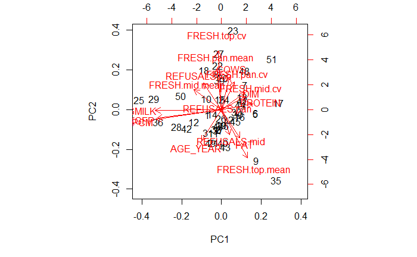

`r`r fviz_pca_var(DATASET2.pca, col.var = )

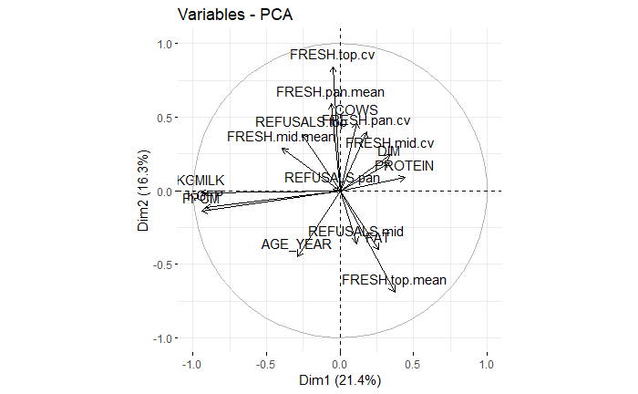

`r`r p <- fviz_pca_biplot(DATASET2.pca, label=, invisible =, col.var = , xlim=c(-8, 8), ylim=c(-8, 8)) p

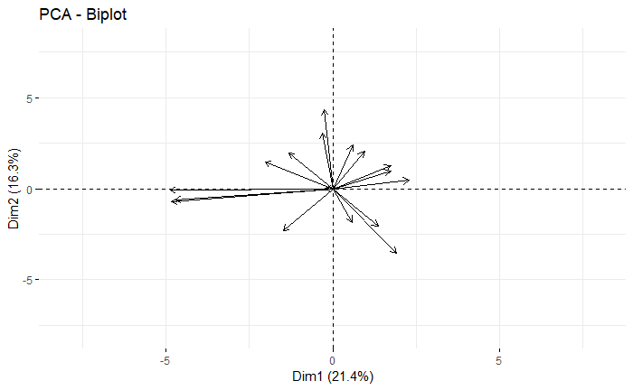

`r`r p <- p + annotate(, x=-0.15, y=6.2, label=expression([TOP.CV]), size=3, angle=274) + annotate(, x=-0.5, y=5.3, label=expression([PAN.MEAN]), size=3, angle=280) + annotate(, x=0.8, y=3.5, label=expression(), size=3, angle=70) + annotate(, x=1.5, y=3.5, label=expression([PAN.CV]), size=3, angle=55) + annotate(, x=2.75, y=2.1, label=expression([MID.CV]), size=3, angle=20) + annotate(, x=2.2, y=1.2, label=expression(), size=3, angle=18) + annotate(, x=3, y=.7, label=expression(), size=3, angle=10) + annotate(, x=1.8, y=-2.5, label=expression(), size=3, angle=320) + annotate(, x=2.7, y=-5, label=expression([TOP.MEAN]), size=3, angle=315) + annotate(, x=1, y=-3.5, label=expression([MID]), size=3, angle=300) + annotate(, x=-1.8, y=-2.8, label=expression(), size=3, angle=50) + annotate(, x=-6, y=-.8, label=expression(; KGFP), size=3, angle=5) + annotate(, x=-5.7, y=0, label=expression(), size=3, angle=0) + annotate(, x=-1.7, y=0.5, label=expression([PAN]), size=3, angle=0) + annotate(, x=-3.2, y=2.3, label=expression([MID.MEAN]), size=3, angle=345) + annotate(, x=-2.2, y=3.5, label=expression([TOP]), size=3, angle=320) p <- p + labs(x = 1 (21.4%), y = 2 (16.3%)) p

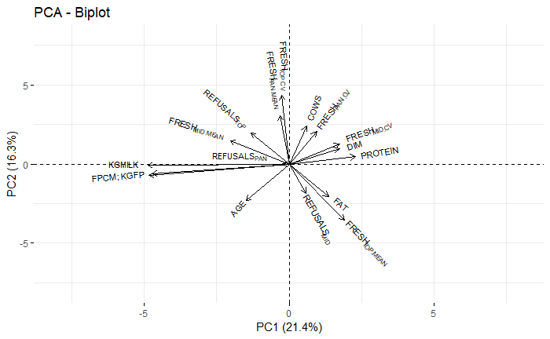

`r`r g <- fviz_pca_biplot(DATASET2.pca, geom=c(, ), invisible = , col.ind = , gradient.cols = c(#00AFBB, #E7B800, #FC4E07), xlim=c(-8, 8), ylim=c(-8, 8)) g <- g + labs(x = 1 (21.4%), y = 2 (16.3%)) print (g)

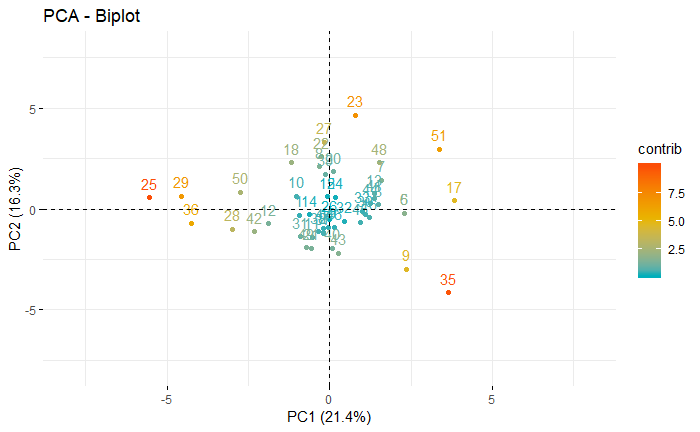

`r`r DATASETLAST <- DATASET2[-c(4,34), ] fviz_pca_biplot(DATASET2.pca, geom=c(, ), habillage = DATASETLAST$SPOILAGE, palette = c(#00AFBB, #FC4E07), addEllipses = TRUE, invisible = , col.var = )

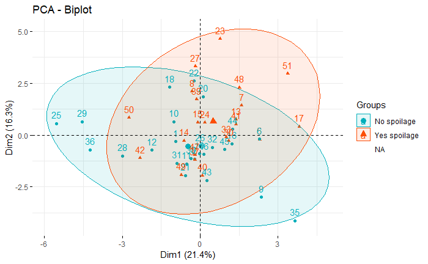

`r`r library(devtools) install_github(/ggbiplot, force=TRUE)

[output not shown]

`r`r View(diff)

[output not shown]

`r`r library(ggbiplot) g <- ggbiplot(DATASET2.pca, choices = c(1,2), obs.scale = 1, var.scale = 1) g <- g + geom_point(aes(size = DATASETLAST$FPCM, color = DATASETLAST$SPOILAGE)) g <- g + theme(legend.direction = ‘horizontal’, legend.position = ‘top’) g <- g + theme_minimal() print(g)

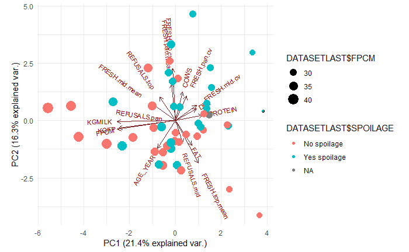

`r`r g <- ggbiplot(DATASET2.pca, choices = c(1,2), obs.scale = 1, var.scale = 1, var.axes=FALSE) + geom_point(aes(size = DATASETLAST$FPCM, color = DATASETLAST$SPOILAGE)) + theme(legend.direction = ‘horizontal’, legend.position = ‘top’) + scale_size_continuous(name = (kg)) + scale_color_manual(values = c(#00AFBB, #FC4E07), name = ) + labs(x = 1 (21.4%), y = 2 (16.3%)) + theme_minimal() print(g)

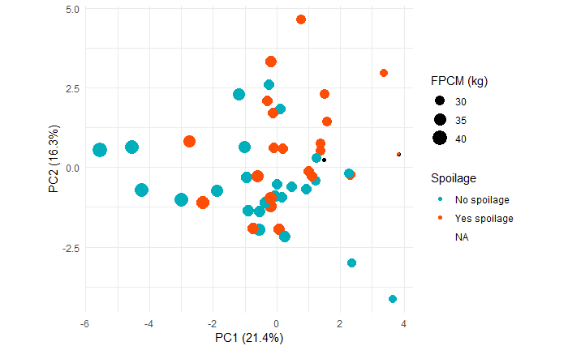

`r`r fviz_pca_biplot(DATASET2.pca, geom=c(, ), habillage = DATASETLAST$POSITION, palette = c(#FC4E07, #00AFBB), addEllipses = TRUE, invisible = , col.var = )

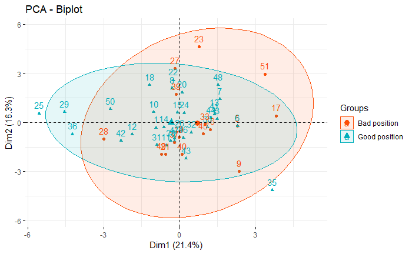

`r`r g <- ggbiplot(DATASET2.pca, choices = c(1,2), obs.scale = 1, var.scale = 1, var.axes=FALSE) + geom_point(aes(size = DATASETLAST$FPCM, color = DATASETLAST$POSITION)) + theme(legend.direction = ‘horizontal’, legend.position = ‘top’) + scale_size_continuous(name = (kg)) + scale_color_manual (values = c(#FC4E07, #00AFBB), name = , breaks=c(position, position)) + labs(x = 1 (21.4%), y = 2 (16.3%)) + theme_minimal() print(g)

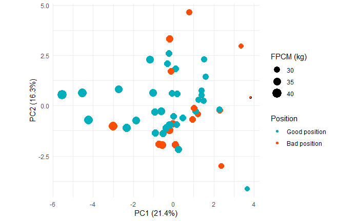

`r`r fviz_pca_biplot(DATASET2.pca, geom=c(, ), habillage = DATASETLAST$MIXING_AFTER_LAST , addEllipses = TRUE, ellipse.type = , invisible = , label = , col.var = )

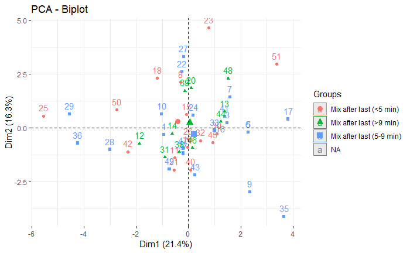

`r`r fviz_pca_biplot(DATASET2.pca, geom=c(, ), habillage = DATASETLAST$MOVEMENT, addEllipses = TRUE, ellipse.type = , label = , invisible = , col.var = )

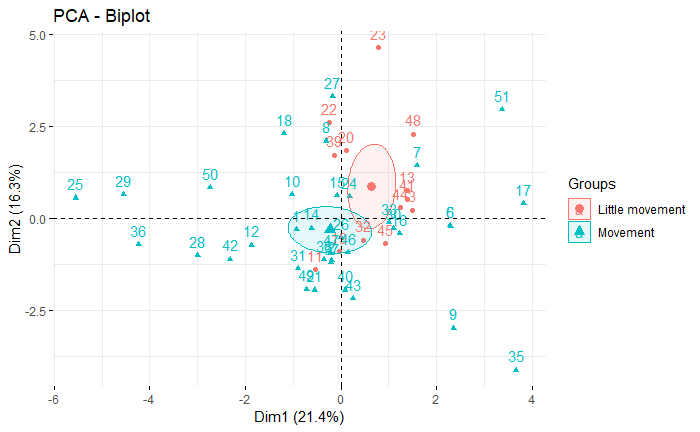